# Demystifying R: DSSS x PSU workshop

Warren Ho Kin

March 2021

| Topics Covered | Min |
| --- | --- |
| Introduction | 5 |
| Introduction to R studio | 5 |
| Data manipulation | 5 |
| Reading Data | 5 |
| Working with Packages and Libraries | 5 |
| Beginner visualization | 10 |
| Context on the data | 5 |
| Data cleaning | 10 |
| Data exploration! | 10 |

## R studio

- R/ R Studio/ Jupyter / R Studio Cloud
- Code editor: Where you can read and edit code
- Workspace/Variable environment: Where data and variables are listed
- Console: Code log and output for code
- R Markdown vs R script

### Useful shortcuts

- Running line or selection of code: **Ctrl + Enter**
- Running Code Chunks: **Ctrl + Shift + Enter**
- Insert new code chunk : **Ctrl + Alt + I**

## Data manipulation: A fancy calculator

There are often more than one way to do things in R

```r
# literal
1+2+3+4+5

# Colon form
1:100

# function
seq(1,100,10)

# Function of function
sum(seq(1:5))

# Vectors
myNumericVector = c(1:5)
sum(myNumericVector)

# Vector addition
myOtherNumVector = seq(from = 10, to = 50, by = 10)
myNumericVector + myOtherNumVector

# # Need help to know what functions do?
# help(seq)
# ?seq
```

[output not shown]

### Reading Data

One of the main ways people use R is to work with data to do visualization or statistical analysis. To do this, it’s best to put the data file in the same folder as your **R Project**, and then use a function to read it in to your R Session.

```r
# Tell your program where you files are
setwd("C:/Users/Whokin/OneDrive - sfu.ca/University/Courses/DSSS/R workshop")
myData <- read.csv("totally_normal_data.csv", header = FALSE)
```

The head() function is helpful to see what the data looks like. So is the str() function.

```r
head(myData, n = 10)
```

```
##         V1      V2
## 1  55.3846 97.1795
## 2  51.5385 96.0256
## 3  46.1538 94.4872
## 4  42.8205 91.4103
## 5  40.7692 88.3333
## 6  38.7179 84.8718
## 7  35.6410 79.8718
## 8  33.0769 77.5641
## 9  28.9744 74.4872
## 10 26.1538 71.4103
```

```r
str(myData)
```

```
## 'data.frame':    142 obs. of  2 variables:
##  $ V1: num  55.4 51.5 46.2 42.8 40.8 ...
##  $ V2: num  97.2 96 94.5 91.4 88.3 ...
```

The summary() function helps understand the distribution of your data.

```r
summary(myData)
```

```
##        V1              V2
##  Min.   :22.31   Min.   : 2.949
##  1st Qu.:44.10   1st Qu.:25.288
##  Median :53.33   Median :46.026
##  Mean   :54.26   Mean   :47.832
##  3rd Qu.:64.74   3rd Qu.:68.526
##  Max.   :98.21   Max.   :99.487
```

Rename the columns to something descriptive.

```r
colnames(myData) <- c("Barney", "Friends")
summary(myData)
```

```
##      Barney         Friends
##  Min.   :22.31   Min.   : 2.949
##  1st Qu.:44.10   1st Qu.:25.288
##  Median :53.33   Median :46.026
##  Mean   :54.26   Mean   :47.832
##  3rd Qu.:64.74   3rd Qu.:68.526
##  Max.   :98.21   Max.   :99.487
```

### Working with Packages and Libraries

The R language comes with a lot of features built-in, especially for data manipulation. R is also an open-source language which mean that anyone can contribute to the language. This is done through **packages** which are bundles of code to add extra features.

```r
# ??tidyverse
# install.packages(tidyverse)
# install.packages(ggplot2)
library(tidyverse) # Data exploration and function pipeline
library(ggplot2) # Visualization
```

## Beginner Visualization

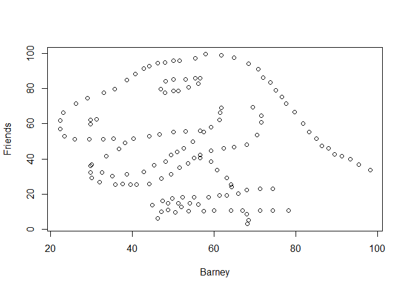

```r
# Base R
plot(myData)
```

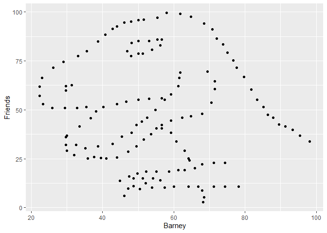

```r
# ggplot
ggplot(myData, aes(x = Barney, y = Friends))+
  geom_point() # Data points layers
```

Credit for the dataset to: https://cran.r-project.org/web/packages/datasauRus/vignettes/Datasaurus.html

# Colours and pretty plots

```r
# Libraries for colouring
library(ggthemes)
library(viridis)
```

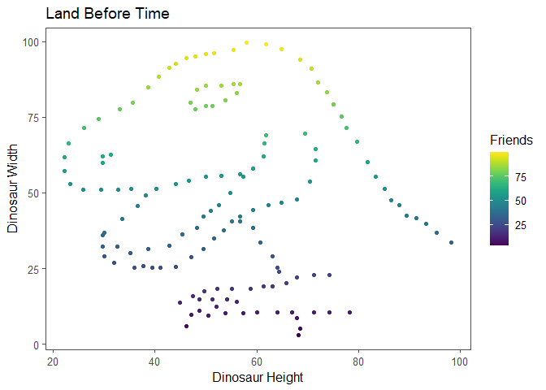

```r
ggplot(myData, aes(x = Barney, y = Friends, color = Friends))+
  geom_point()+
  ggtitle("Land Before Time")+
  xlab("Dinosaur Height")+
  ylab("Dinosaur Width")+
  theme_few()+scale_color_viridis()
```

```r
# # Plots are data objects where we can stack layers
# p <- ggplot(myData, aes(x = Barney, y = Friends, color = Friends))+
#   geom_point()
#
# p = p +
#   ggtitle("Land Before Time")+
#   xlab("Dinosaur Height")+
#   ylab("Dinosaur Width")+
#   theme_few()+scale_color_viridis()
# p
```

Let’s get our hands dirty now.

# 5 Personality data

### Research Question/Problem Statement

What is our research question?  
- Hypothesis: Does scoring high in conscientiousness correlate with low neuroticism?

### Data Collection/Measurement Strategy

What type of data is required  
- Data sources: Open Source Psychometrics Project  
- Dataset contains 1,015,342 questionnaire but we will work on the first 1,000  
- URL: https://www.kaggle.com/tunguz/big-five-personality-test

### Reading Data

We often want to import data instead of generating or typing them out.  
Let’s import the first 1,000 responses to our survey.

Note: The file is over a million rows large so we cut it down for practical use here.  
We wanted to offer a real-life size file to play with but for now, we’ll stick to a small subset.  
I made a small script to prepare the data a bit. Feel free to have a look at it.

```r
source("data_preperation.R")

# Load data
df <- read.csv("personality-data-subset.csv")
```

It’s often useful to look at the data before doing anything else.

```r
# Let's look at the size of our data
dim(df)

# Peek at the first 10 lines
head(df,n = 10) # If n is omitted, it also defaults to 5

# look at the data type of the columns and some content
# Note: This can quickly become overwhelming with a large number of columns
df %>% filter() %>% glimpse()
```

[output not shown]

### Cleaning

In many cases, data is dirty and messy. Let’s search for pesky missing values. There are multiple ways to deal with those but for now we will just get rid of them.

```r
# Check the whole data frame for missing values
any(is.na(df))

# Number of NA for each column
na_count = sapply(df, function(x) sum(is.na(x)))
print(na_count)

# # Bar plot form
# na_count %>%
#   barplot(main ="Count of missing values per column",
#           horiz = TRUE)

# Look at how many rows are with NA values
sum(!complete.cases(df))
sum(!complete.cases(df)) / nrow(df) # In percentage

# Use filtering from dyplyr. This finds the rows where there are NAs
df_clean = na.omit(df)
```

[output not shown]

# Participants’ nationality distribution

```r
# Get the count of participants by country
countries <- df_clean %>%
  group_by(country) %>%
  tally(sort = TRUE) %>%
  slice(1:5)

head(countries, n = 10)
```

```
## # A tibble: 5 x 2
##   country     n
##   <chr>   <int>
## 1 US        400
## 2 GB        148
## 3 CA         53
## 4 DE         23
## 5 IN         21
```

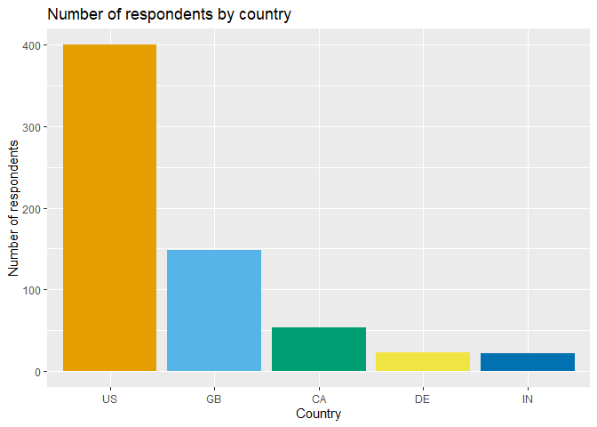

```r
ggplot(countries, aes(reorder(country, -n), n)) +
  geom_bar(stat = 'identity', fill= c("#E69F00", "#56B4E9", "#009E73",
          "#F0E442", "#0072B2")) +
  ggtitle("Number of respondents by country") +
  xlab("Country") + ylab("Number of respondents")
```

# Distribution

For each question, show the distribution of responses

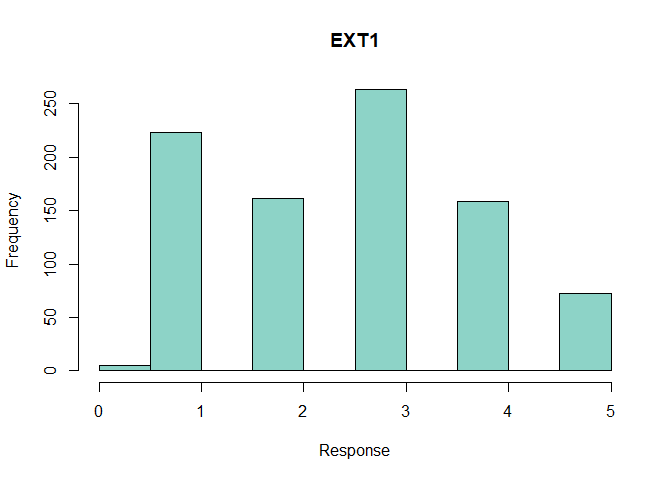

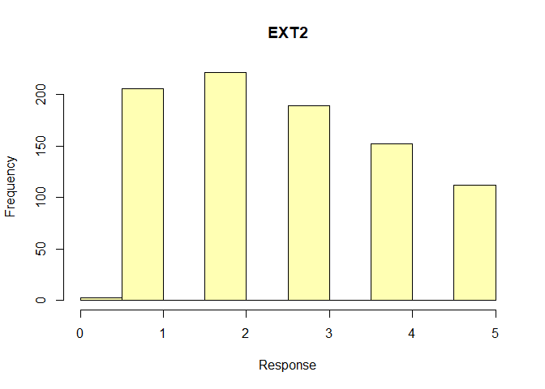

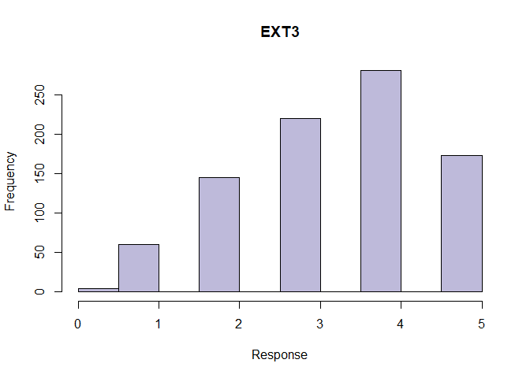

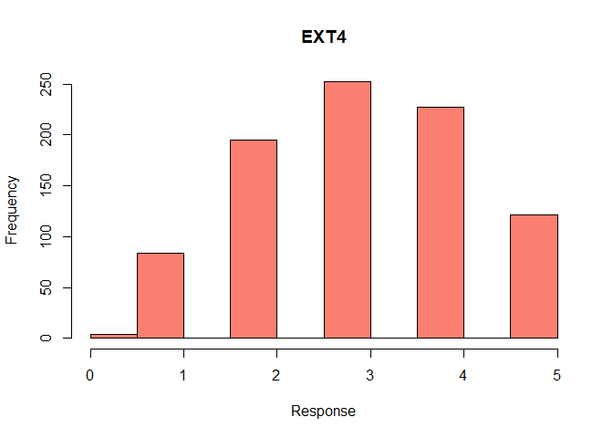

```r
# install.packages("ggpubr")
# install.packages("RColorBrewer")

library(ggpubr)
library(RColorBrewer)
# display.brewer.all()

for(i in 1:4){
  question = paste("EXT", i, sep = "")
  hist(df_clean[, question],
       main = question,
       xlab = "Response",
       col = brewer.pal(10 , "Set3")[i])
}
```

It’s often easier to work with subsets of data at a time

```r
# Find entries where the column name starts with a key text
EXT = df_clean[,startsWith(colnames(df_clean), prefix = "EXT")]
EST = df_clean[,startsWith(colnames(df_clean), prefix = "EST")]
AGR = df_clean[,startsWith(colnames(df_clean), prefix = "AGR")]
CSN = df_clean[,startsWith(colnames(df_clean), prefix = "CSN")]
OPN = df_clean[,startsWith(colnames(df_clean), prefix = "OPN")]
# 'Extroversion   -   Neuroticism   -   Agreeableness   -   Conscientiousness   -   Openness'
```

We want to see the correlation between questions

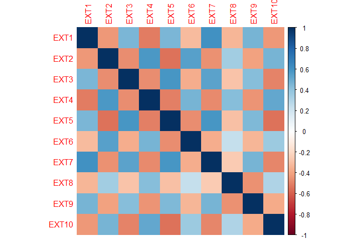

```r
library(corrplot)
EXT_corr = cor(EXT[1:10])
corrplot(EXT_corr, method = "color")
```

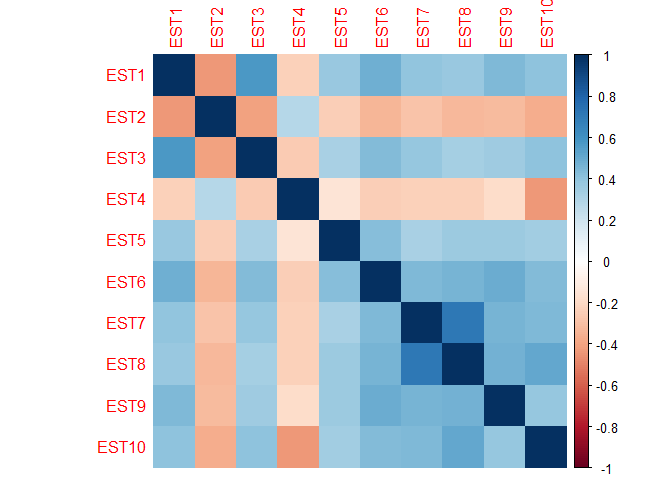

```r
EST_corr = cor(EST[1:10])
corrplot(EST_corr, method = "color")
```

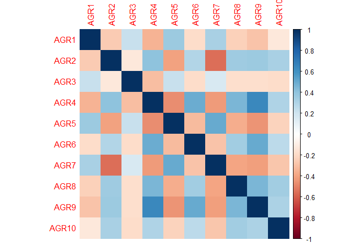

```r
AGR_corr = cor(AGR[1:10])
corrplot(AGR_corr, method = "color")
```

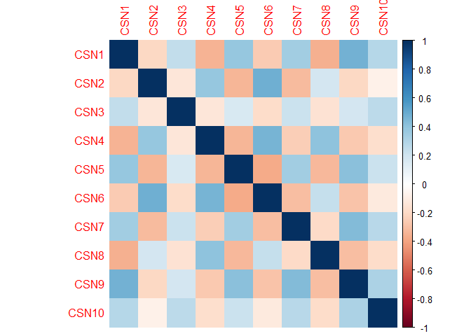

```r
CSN_corr = cor(CSN[1:10])
corrplot(CSN_corr, method = "color")
```

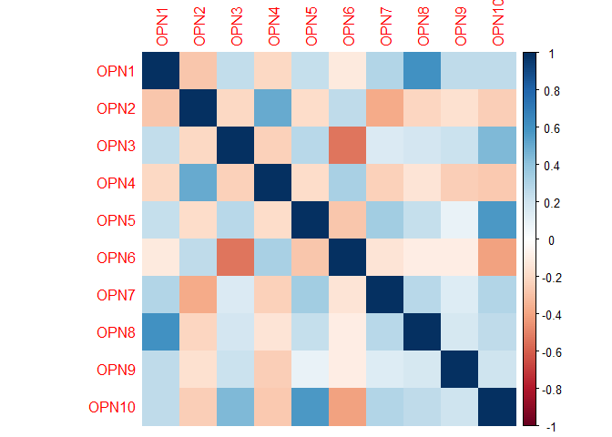

```r
OPN_corr = cor(OPN[1:10])
corrplot(OPN_corr, method = "color")
```

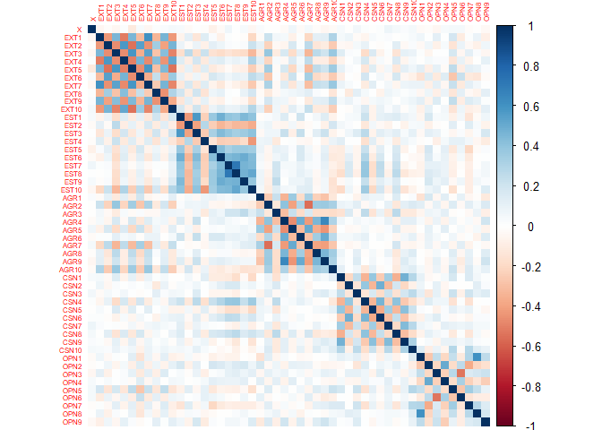

```r
questions_corr = cor(x = df_clean[1:50])
corrplot(questions_corr, method = "color", tl.cex = .5)
```

# Connect with the Data Science Student Society:

Discord: https://discord.gg/rcUvvYBUSF  
FB: SFU Data Science Student Society - DSSS (https://www.facebook.com/sfudsss)

# Connect with the Psychology Student Union:

IG: sfu_psu (https://www.instagram.com/sfu_psu/)  
FB: SFU Psychology Student Union (https://www.facebook.com/SFUPsychologyStudentUnion)  
Discord: https://discord.gg/ZahuFF2Pkp

### Useful link

https://www.rdocumentation.org/ https://www.yanqixu.com/My_R_Cheatsheet/data_cleaning_cheatsheet.html#what%E2%80%99s_this_for https://www.datanovia.com/en/blog/ggplot-colors-best-tricks-you-will-love/